# A Self Assessment of Fundamentals

DDD: Elements of Statistical Machine Learning & Politics of Data

Ayush Patel

At Azim Premji University, Bhopal

23 Mar, 2026

# Hello

I am Ayush.

I am a researcher working at the intersection of data, development and economics.

I am a [RStudio (Posit) certified tidyverse Instructor.](https://education.rstudio.com/trainers/people/patel+ayush/)

I am a Researcher at [Oxford Poverty and Human development Initiative (OPHI)](https://ophi.org.uk/), at the University of Oxford.

[figure not shown]

[Hello (Eh bonjour– donc–.) by Charles Motte](https://www.metmuseum.org/art/collection/search/392118%22Well)

# How many can you get?

## Replicate exe 1

Data: starwars

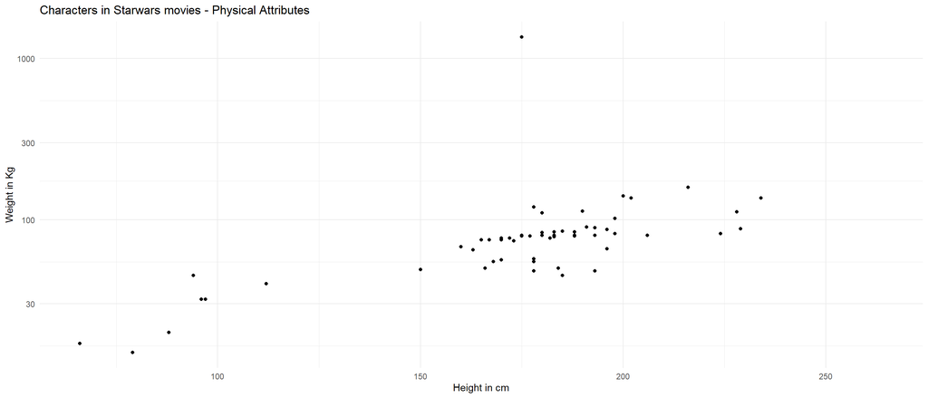

## Replicate exe 2

data: storms

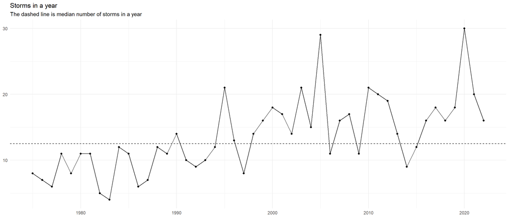

## Replicate exe 3

Data: storms

| name | duration_begin | duration_end | duration |
| --- | --- | --- | --- |
| AL011993 | 1993-05-31 12:00:00 | 1993-06-03 00:00:00 | 2d 12H 0M 0S |
| AL012000 | 2000-06-07 18:00:00 | 2000-06-08 12:00:00 | 18H 0M 0S |
| AL021992 | 1992-06-25 12:00:00 | 1992-06-26 12:00:00 | 1d 0H 0M 0S |
| AL021994 | 1994-07-20 06:00:00 | 1994-07-21 06:00:00 | 1d 0H 0M 0S |
| AL021999 | 1999-07-02 18:00:00 | 1999-07-03 06:00:00 | 12H 0M 0S |
| AL022000 | 2000-06-23 00:00:00 | 2000-06-25 18:00:00 | 2d 18H 0M 0S |
| AL022001 | 2001-07-11 18:00:00 | 2001-07-12 18:00:00 | 1d 0H 0M 0S |
| AL022003 | 2003-06-11 00:00:00 | 2003-06-11 18:00:00 | 18H 0M 0S |
| AL022006 | 2006-07-16 12:00:00 | 2006-07-19 12:00:00 | 3d 0H 0M 0S |
| AL031987 | 1987-08-09 12:00:00 | 1987-08-17 06:00:00 | 7d 18H 0M 0S |
| AL031992 | 1992-07-24 18:00:00 | 1992-07-26 12:00:00 | 1d 18H 0M 0S |
| AL041991 | 1991-08-24 12:00:00 | 1991-08-26 00:00:00 | 1d 12H 0M 0S |
| AL042000 | 2000-08-08 12:00:00 | 2000-08-11 12:00:00 | 3d 0H 0M 0S |
| AL051994 | 1994-08-29 12:00:00 | 1994-08-31 12:00:00 | 2d 0H 0M 0S |
| AL061988 | 1988-09-07 00:00:00 | 1988-09-10 00:00:00 | 3d 0H 0M 0S |
| AL061995 | 1995-08-05 18:00:00 | 1995-08-07 12:00:00 | 1d 18H 0M 0S |
| AL061997 | 1997-07-17 06:00:00 | 1997-07-19 00:00:00 | 1d 18H 0M 0S |
| AL062003 | 2003-07-19 18:00:00 | 2003-07-21 12:00:00 | 1d 18H 0M 0S |
| AL071999 | 1999-09-05 18:00:00 | 1999-09-07 12:00:00 | 1d 18H 0M 0S |
| AL072002 | 2002-09-07 12:00:00 | 2002-09-08 12:00:00 | 1d 0H 0M 0S |
| AL072003 | 2003-07-25 12:00:00 | 2003-07-27 00:00:00 | 1d 12H 0M 0S |
| AL081992 | 1992-09-25 12:00:00 | 1992-10-01 12:00:00 | 6d 0H 0M 0S |
| AL081994 | 1994-09-24 12:00:00 | 1994-09-26 18:00:00 | 2d 6H 0M 0S |
| AL091994 | 1994-09-27 12:00:00 | 1994-09-29 00:00:00 | 1d 12H 0M 0S |
| AL092000 | 2000-09-08 18:00:00 | 2000-09-09 12:00:00 | 18H 0M 0S |
| AL092001 | 2001-09-19 18:00:00 | 2001-09-20 06:00:00 | 12H 0M 0S |
| AL092003 | 2003-08-21 18:00:00 | 2003-08-22 12:00:00 | 18H 0M 0S |
| AL101991 | 1991-10-24 12:00:00 | 1991-10-25 12:00:00 | 1d 0H 0M 0S |
| AL101993 | 1993-09-29 18:00:00 | 1993-09-30 18:00:00 | 1d 0H 0M 0S |
| AL101994 | 1994-09-29 06:00:00 | 1994-09-30 18:00:00 | 1d 12H 0M 0S |

[output cut: 230 more lines]

## Replicate exe 4

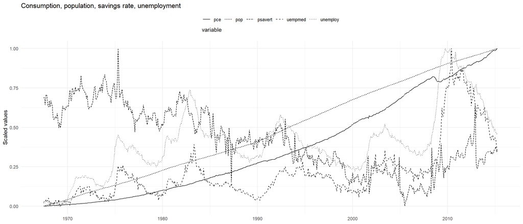

## Replicate exe 5

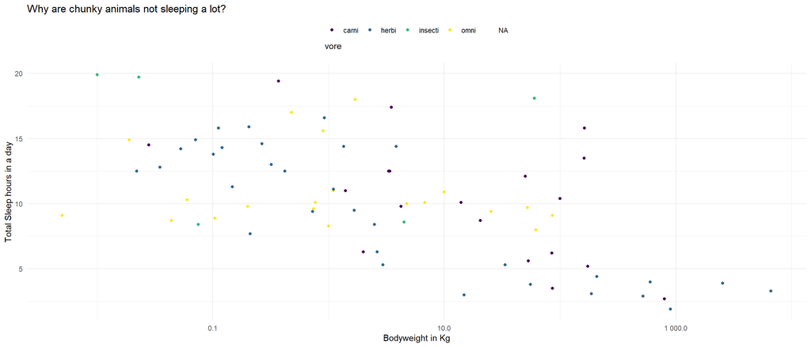

## Replicate exe 6

Data: starwars

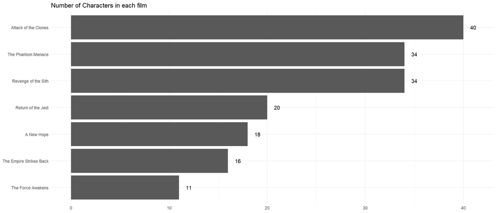

## Exe - 7

Use `penguins` data from the {palmerpenguins} package. Consider all combinations of species-sex as a unique group. From the data extract the observations that are equal to or above the third standard deviation of body mass for a respective group.

## Exe - 8

Use the `world_bank_pop` data from the {tidyr} package. Show how population growth has changed for India and its neighbours (shared boundary)

## Exe - 9

Use `us_rent_income` data from the {tidyr} package. Create a table that show the ratio of rent to income for each state, Arrange it in descending order.

## Exe - 10

How many instances in the `txhousing` data are such where the mean sale value is more than 125% of the median sale value?

## Exe - 11

Show monthly trends of accidental deaths for each year using the data `accdeaths`

## Exe - 12

Find the averge age for patients with status `D` (dead) for each transmission category using the `Aids2` data.

## Exe - 13

Use `edibnb` from {dsbox}. Create a faceted histogram where each facet represents a neighbourhood and displays the distribution of Airbnb prices in that neighbourhood. Think critically about whether it makes more sense to stack the facets on top of each other in a column, lay them out in a row, or wrap them around. Along with your visualisation, include your reasoning for the layout you chose for your facets.

use `devtools::install_github("tidyverse/dsbox")` install the package {dsbox}

## Exe - 14

Answer these about the `lego_sales` data from {dsbox}

1. What are the three most common first names of purchasers?
2. What are the three most common themes of Lego sets purchased?
3. Among the most common theme of Lego sets purchased, what is the most common subtheme?
4. Create a new variable called age_group and group the ages into the following categories: “18 and under”, “19 - 25”, “26 - 35”, “36 - 50”, “51 and over”.
5. Which age group has purchased the highest number of Lego sets.